# Análisis comparativo de la relación calidad-precio en vehículos por tipo de motorización: eléctrico, híbrido y de combustible en el mercado global 2025

Angel Pastrano y Valeria Barreto

2025-10-16

# **Planteamiento del problema**

La industria automotriz está en una transición. Los vehículos eléctricos e híbridos han crecido en popularidad, pero a menudo se perciben como opciones más caras. Esta percepción plantea una pregunta crítica para los consumidores: ¿Cuál de las tres principales tecnologías de motorización *(eléctrico, híbrido o de combustible fósil)* ofrece la mejor relación calidad-precio, considerando el rendimiento del motor frente a su costo de compra inicial?

## **Objetivo general**

Determinar la categoría de motorización (eléctrica, híbrida o combustible fósil) que presenta la mejor relación calidad-precio en el mercado automotriz, basándose en un análisis descriptivo de las características del “cars dataset 2025”

## **Objetivos específicos**

# **Marco de referencia**

## **Marco teórico**

El análisis descriptivo se fundamenta en la hipótesis de que la eficiencia de costo por unidad de potencia **RCP** variará significativamente entre las tres categorías de motorización. Se espera que los vehículos con tecnología más establecida *(Combustible Fósil)* puedan ofrecer un **RCP** alto debido a los menores costos de producción en comparación con las tecnologías de baterías *(Híbridos y Eléctricos)*, aunque el estudio busca identificar el grupo con el valor medio de **RCP** más alto.

Un valor más alto en este índice indica una mejor relación calidad-precio, ya que el vehículo ofrece mayor potencia *(calidad)* por cada unidad de costo *(precio)*.

## **Marco metodológico**

### **Enfoque y tipo de investigación**

El estudio empleará un enfoque cuantitativo para llevar a cabo una investigación descriptiva y comparativa.

Enfoque Cuantitativo: Permite la manipulación y el análisis de datos numéricos del dataset *(precio, índice de calidad-precio)* mediante técnicas estadísticas *(media, mediana, desviación estándar)* para obtener resultados.

### **Fuente de datos**

Se utiliza el conjunto de datos Cars_Datasets_2025.csv, que contiene registros de precio, marca, motorizacion y potencia *(Horses Power)*.

### **Período de referencia**

El análisis se centra en el mercado automotriz de 2025. Por lo tanto, la investigación y sus conclusiones estan ancladas a la información y de los datos disponibles para el año 2025.

### **Procesamiento y análisis de datos**

1. Preprocesamiento y Cálculo de Variables

· Limpieza de datos: Se convirtieron precios *(eliminando “$”, comas)* y especificaciones técnicas *(caballos de fuerza, velocidad, aceleración)* a valores numéricos. · Manejo de datos faltantes: Se eliminaron registros incompletos o con precio cero. · Métricas clave: · Índice de Calidad: Combina potencia, velocidad y aceleración *(HP + Velocidad - 10×Aceleración)* · Relación QPR: (Calidad/Precio)×1000 - representa puntos de calidad por cada $1,000 USD

2. Análisis Individual por Modelo *(Top 10)*

· Se identificaron los 10 modelos con mejor relación calidad-precio · Visualización con gráfico de barras horizontal, diferenciando por tipo de motorización

3. Análisis Comparativo por Marca

· Agregación por fabricante, calculando promedios de QPR y precio · Filtro de robustez: solo marcas con ≥2 modelos · Identificación del Top 10 de marcas con mejor QPR promedio · Visualización similar con gráfico de barras horizontal

Propósito: Identificar los vehículos y marcas que ofrecen mejor rendimiento por unidad de precio invertido, utilizando métricas estandarizadas y análisis a dos niveles *(modelo individual y comparativa de fabricantes)*.

# TOP 10 MEJORES CARROS CALIDAD/PRECIO

Este es un ranking basado en el índice QPR (puntos de calidad por cada $1,000 USD), para asi encontrar a los vehículos con mayor eficiencia en calidad-precio del mercado. A través de este estudio, identificamos no solo los vehículos con el mejor balance, sino que ademas aquellos cuyo alto precio no necesariamente se traduce en una superioridad en calidad, guiando tu decisión hacia la mejor desicion de compra.

Ahora bien, ¿cómo vamos a saber qué carro es más rentable que otro? Los gustos personales y las percepciones de lo “superior” varían enormemente entre compradores. Por eso, para eliminar subjetividades y ofrecer una evaluación justa y comparable, desarrollamos una fórmula basada en datos técnicos que asigna puntos de calidad a cada vehículo.

La Fórmula es la siguiente: Puntos de Calidad = Potencia + Velocidad Máxima – (10 × Aceleración 0-100 km/h)

¿Por qué estos tres factores? Porque representan, de forma sencilla y universal, el rendimiento básico de un auto:

Potencia (cv) y Velocidad Máxima (km/h): A mayor potencia y velocidad, más capacidad de respuesta y desempeño.

Aceleración (segundos 0-100 km/h): Un valor bajo en aceleración es mejor (menos tiempo = más rápido). Por eso multiplicamos la aceleración por 10 y la restamos:

Un auto rápido (ej. 5 segundos) resta solo 50 puntos.

Un auto lento (ej. 12 segundos) resta 120 puntos.

Ejemplo: Un auto con 150 cv, 200 km/h de velocidad máxima y aceleración de 8 segundos tendría: Puntos de Calidad = 150 + 200 – (10 × 8) = 270 puntos

Paso 2: La Relación Calidad-Precio (QPR)

Pero no basta con saber cuánto rinde un auto, ¿Vale la pena pagar su precio?, para responder esto, convertimos los Puntos de Calidad en rentabilidad real:

Fórmula QPR = (Puntos de Calidad ÷ Precio) × 1000

Esto nos dice: ¿Cuántos puntos de calidad obtienes por cada $1,000 USD que gastas?

Más alto el QPR = Más rendimiento por tu dinero.

Más bajo el QPR = Menos eficiencia en lo que pagas.

```
##    Fabricante       Modelo  Motorización Precio Promedio (USD)
## 1      Nissan        Urvan        Diesel                 28000
## 2      NISSAN         370Z        Petrol                 30000
## 3   Chevrolet       Camaro        Petrol                 26400
## 4     HYUNDAI     Veloster        Petrol                 25000
## 5      TOYOTA        CAMRY Petrol/Hybrid                 27000
## 6         BMW M135i XDRIVE        Petrol                 30000
## 7      Nissan       Lucino        Petrol                 12000
## 8      NISSAN      Z PROTO        Petrol                 40000
## 9   Chevrolet    Camaro SS        Petrol                 43500
## 10     Nissan   Silvia S13        Petrol                 20000
##    Índice de Calidad Relación QPR (Puntos/1k USD)
## 1               2488                     88.85714
## 2                535                     17.83333
## 3                461                     17.46212
## 4                435                     17.40000
## 5                461                     17.07407
## 6                504                     16.80000
## 7                195                     16.25000
## 8                649                     16.22500
## 9                702                     16.13793
## 10               322                     16.10000
```

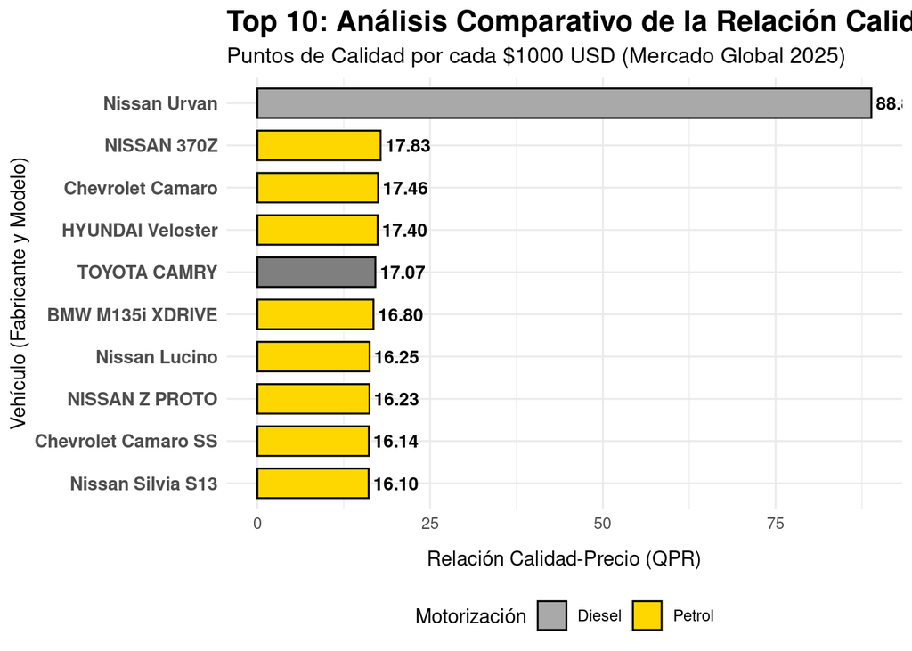

# COMPARATIVA POR MARCAS

Bloque de Comparativa y Promedios por Marca

Este bloque calcula el QPR promedio, el precio promedio y el número de modelos por cada fabricante, y selecciona las 10 marcas con mejor QPR.

```
## # A tibble: 10 × 4
##    Fabricante    Modelos QPR_Promedio Precio_Promedio_USD
##    <chr>           <int>        <dbl>               <dbl>
##  1 NISSAN             10        13.5               39600
##  2 HONDA               7        11.8               29364.
##  3 MAHINDRA            3        11.7               18400
##  4 MARUTI SUZUKI       3        11.3               12067.
##  5 HYUNDAI            23        11.0               31496.
##  6 Chevrolet          58        10.1               44963.
##  7 Kia                54         9.84              36759.
##  8 KIA                16         9.77              34094.
##  9 Nissan            149         9.26              60510.
## 10 Cadillac           20         9.23              62178.
```

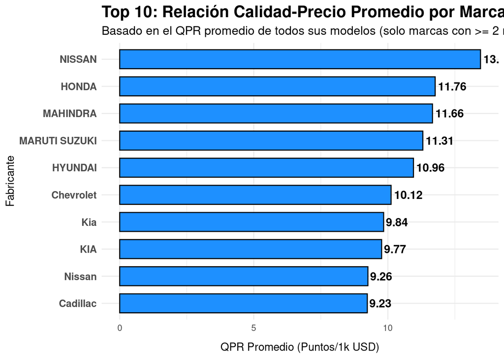